# Taller 7

Métodos Computacionales para Políticas Públicas - URosario

**Entrega: viernes 3-abr-2020 11:59 PM**

**[Monica Alejandra Robayo Gonzalez]**  
[monica.robayo@urosario.edu.co]

## Instrucciones:

- Guarde una copia de este *Jupyter Notebook* en su computador, idealmente en una carpeta destinada al material del curso.
- Modifique el nombre del archivo del *notebook*, agregando al final un guión inferior y su nombre y apellido, separados estos últimos por otro guión inferior. Por ejemplo, mi *notebook* se llamaría: mcpp_taller7_santiago_matallana
- Marque el *notebook* con su nombre y e-mail en el bloque verde arriba. Reemplace el texto "[Su nombre acá]" con su nombre y apellido. Similar para su e-mail.
- Desarrolle la totalidad del taller sobre este *notebook*, insertando las celdas que sea necesario debajo de cada pregunta. Haga buen uso de las celdas para código y de las celdas tipo *markdown* según el caso.
- Recuerde salvar periódicamente sus avances.
- Cuando termine el taller:
  1. Descárguelo en PDF. Si tiene algún problema con la conversión, descárguelo en HTML.
  2. Suba todos los archivos a su repositorio en GitHub, en una carpeta destinada exclusivamente para este taller, antes de la fecha y hora límites.

(Todos los ejercicios tienen el mismo valor.)

Este taller tiene dos partes. Una obligatoria, relativamente fácil, y otra voluntaria y más retadora. Los invito a intentar desarrollar el taller en su totalidad. (Buen plan para el aislamiento obligatorio.)

En este taller exploraremos los datos de crimen de Chicago.

Descargue los datos de crimen del Chicago Data Portal solo para el año 2015 (https://data.cityofchicago.org/Public-Safety/Crimes-2001-to-present/ijzp-q8t2/data).

### Parte obligatoria

```python
import pandas as pd
import numpy as np
import matplotlib.pyplot as plt
plt.rcParams["figure.figsize"] = [18.0, 8.0]
plt.style.use('ggplot') # R
```

### 1.

Calcule el número de crímenes en cada Community Area en 2015. Haga un gráfico de barras que lo ilustre.

```python
crimes = pd.read_csv("Crimes_2015.csv")
```

```python
crimes
```

|  | ID | Case Number | Date | Block | IUCR | Primary Type | Description | Location Description | Arrest | Domestic | ... | Ward | Community Area | FBI Code | X Coordinate | Y Coordinate | Year | Updated On | Latitude | Longitude | Location |
| --- | --- | --- | --- | --- | --- | --- | --- | --- | --- | --- | --- | --- | --- | --- | --- | --- | --- | --- | --- | --- | --- |
| 0 | 10201852 | HY389096 | 01/01/2015 12:00:00 AM | 008XX N MAPLEWOOD AVE | 2825 | OTHER OFFENSE | HARASSMENT BY TELEPHONE | APARTMENT | False | True | ... | 1 | 24 | 26 | 1159250.0 | 1905420.0 | 2015 | 08/20/2015 04:17:37 PM | 41.896198 | -87.690553 | (41.896197984, -87.690552821) |
| 1 | 10060114 | HY239140 | 01/01/2015 12:00:00 AM | 069XX S CORNELL AVE | 1751 | OFFENSE INVOLVING CHILDREN | CRIM SEX ABUSE BY FAM MEMBER | RESIDENCE | False | False | ... | 5 | 43 | 20 | 1188551.0 | 1859284.0 | 2015 | 08/17/2015 03:03:40 PM | 41.768946 | -87.584415 | (41.768945532, -87.584414851) |
| 2 | 10210454 | HY397301 | 01/01/2015 12:00:00 AM | 049XX W WABANSIA AVE | 0266 | CRIM SEXUAL ASSAULT | PREDATORY | RESIDENCE | False | True | ... | 37 | 25 | 02 | NaN | NaN | 2015 | 08/31/2015 03:43:09 PM | NaN | NaN | NaN |
| 3 | 10025440 | HY214766 | 01/01/2015 12:00:00 AM | 004XX E 80TH ST | 1154 | DECEPTIVE PRACTICE | FINANCIAL IDENTITY THEFT $300 AND UNDER | RESIDENCE | False | True | ... | 6 | 44 | 11 | 1180776.0 | 1852066.0 | 2015 | 08/17/2015 03:03:40 PM | 41.749321 | -87.613135 | (41.749320815, -87.613135423) |
| 4 | 10225520 | HY412735 | 01/01/2015 12:00:00 AM | 075XX S BLACKSTONE AVE | 1153 | DECEPTIVE PRACTICE | FINANCIAL IDENTITY THEFT OVER $ 300 | RESIDENCE | False | False | ... | 5 | 43 | 11 | NaN | NaN | 2015 | 09/10/2015 11:43:14 AM | NaN | NaN | NaN |
| ... | ... | ... | ... | ... | ... | ... | ... | ... | ... | ... | ... | ... | ... | ... | ... | ... | ... | ... | ... | ... | ... |
| 258508 | 10369351 | HZ105321 | 12/31/2015 12:00:00 AM | 0000X W RANDOLPH ST | 1150 | DECEPTIVE PRACTICE | CREDIT CARD FRAUD | OTHER | False | False | ... | 42 | 32 | 11 | 1176135.0 | 1901285.0 | 2015 | 01/15/2016 11:08:45 AM | 41.884487 | -87.628663 | (41.884487451, -87.628662734) |
| 258509 | 10365050 | HZ100594 | 12/31/2015 12:00:00 AM | 038XX N FREMONT ST | 0890 | THEFT | FROM BUILDING | RESIDENCE PORCH/HALLWAY | False | False | ... | 46 | 6 | 06 | 1169575.0 | 1925758.0 | 2015 | 01/07/2016 04:14:34 PM | 41.951788 | -87.652038 | (41.951787958, -87.652037805) |
| 258510 | 10364335 | HY556149 | 12/31/2015 12:00:00 AM | 037XX W ARGYLE ST | 1320 | CRIMINAL DAMAGE | TO VEHICLE | STREET | False | False | ... | 39 | 14 | 14 | 1150389.0 | 1932961.0 | 2015 | 01/07/2016 04:14:34 PM | 41.971950 | -87.722377 | (41.971950353, -87.722376878) |
| 258511 | 10371800 | HZ106801 | 12/31/2015 12:00:00 AM | 019XX N Hoyne Ave | 1153 | DECEPTIVE PRACTICE | FINANCIAL IDENTITY THEFT OVER $ 300 | NaN | False | False | ... | 32 | 22 | 11 | 1162044.0 | 1913082.0 | 2015 | 01/15/2016 11:08:45 AM | 41.917165 | -87.680077 | (41.917165184, -87.680076699) |
| 258512 | 10364402 | HY556328 | 12/31/2015 12:00:00 AM | 051XX S BLACKSTONE AVE | 0810 | THEFT | OVER $500 | STREET | False | False | ... | 4 | 41 | 06 | 1186787.0 | 1871326.0 | 2015 | 01/07/2016 04:14:34 PM | 41.802032 | -87.590499 | (41.802031713, -87.59049938) |

258513 rows × 22 columns

```python
crimes_by_community = crimes.groupby("Community Area")
```

```python
community_crime_count = crimes_by_community["ID"].agg("count")

community_crime_count.to_frame()
```

| Community Area | ID |
| --- | --- |
| 1 | 3519 |
| 2 | 3059 |
| 3 | 3585 |
| 4 | 1747 |
| 5 | 1375 |
| ... | ... |
| 73 | 3109 |
| 74 | 608 |
| 75 | 2052 |
| 76 | 1622 |
| 77 | 2209 |

77 rows × 1 columns

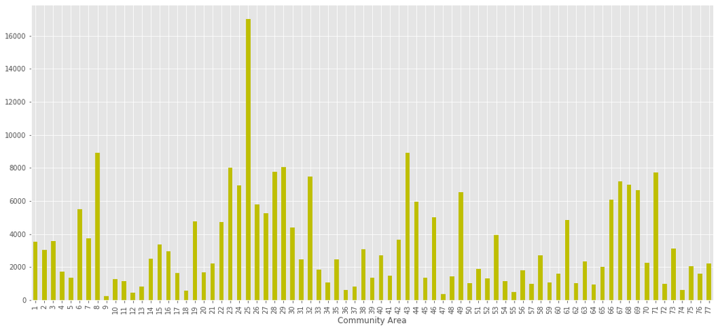

```python
community_crime_count.plot(kind="bar", color = "y");
```

### 2.

Ordene las Community Areas de acuerdo con el número de crímenes. ¿Qué Community Area (por nombre, idealmente) presenta el mayor número de crímenes? ¿El menor?

```python
names= pd.read_csv('Census_Data_-_Selected_socioeconomic_indicators_in_Chicago__2008___2012.csv')
```

```python
names.rename(columns={"Community Area Number": "Community Area"}, inplace=True)
```

```python
names
```

|  | Community Area | COMMUNITY AREA NAME | PERCENT OF HOUSING CROWDED | PERCENT HOUSEHOLDS BELOW POVERTY | PERCENT AGED 16+ UNEMPLOYED | PERCENT AGED 25+ WITHOUT HIGH SCHOOL DIPLOMA | PERCENT AGED UNDER 18 OR OVER 64 | PER CAPITA INCOME | HARDSHIP INDEX |
| --- | --- | --- | --- | --- | --- | --- | --- | --- | --- |
| 0 | 1.0 | Rogers Park | 7.7 | 23.6 | 8.7 | 18.2 | 27.5 | 23939 | 39.0 |
| 1 | 2.0 | West Ridge | 7.8 | 17.2 | 8.8 | 20.8 | 38.5 | 23040 | 46.0 |
| 2 | 3.0 | Uptown | 3.8 | 24.0 | 8.9 | 11.8 | 22.2 | 35787 | 20.0 |
| 3 | 4.0 | Lincoln Square | 3.4 | 10.9 | 8.2 | 13.4 | 25.5 | 37524 | 17.0 |
| 4 | 5.0 | North Center | 0.3 | 7.5 | 5.2 | 4.5 | 26.2 | 57123 | 6.0 |
| ... | ... | ... | ... | ... | ... | ... | ... | ... | ... |
| 73 | 74.0 | Mount Greenwood | 1.0 | 3.4 | 8.7 | 4.3 | 36.8 | 34381 | 16.0 |
| 74 | 75.0 | Morgan Park | 0.8 | 13.2 | 15.0 | 10.8 | 40.3 | 27149 | 30.0 |
| 75 | 76.0 | O'Hare | 3.6 | 15.4 | 7.1 | 10.9 | 30.3 | 25828 | 24.0 |
| 76 | 77.0 | Edgewater | 4.1 | 18.2 | 9.2 | 9.7 | 23.8 | 33385 | 19.0 |
| 77 | NaN | CHICAGO | 4.7 | 19.7 | 12.9 | 19.5 | 33.5 | 28202 | NaN |

78 rows × 9 columns

```python
districName=crimes.merge(names,on="Community Area")
```

```python
crimes_by_community_districName = districName.groupby("COMMUNITY AREA NAME")
```

```python
community_crimes_count = crimes_by_community_districName['ID'].agg('count')
community_crimes_count.to_frame()
```

| COMMUNITY AREA NAME | ID |
| --- | --- |
| Albany Park | 2501 |
| Archer Heights | 986 |
| Armour Square | 1057 |
| Ashburn | 2279 |
| Auburn Gresham | 7733 |
| ... | ... |
| West Lawn | 2027 |
| West Pullman | 3949 |
| West Ridge | 3059 |
| West Town | 6959 |
| Woodlawn | 3665 |

77 rows × 1 columns

```python
community_crimes_count.to_frame().sort_values(by='ID', ascending=False)
```

| COMMUNITY AREA NAME | ID |
| --- | --- |
| Austin | 17020 |
| Near North Side | 8920 |
| South Shore | 8906 |
| North Lawndale | 8039 |
| Humboldt park | 8015 |
| ... | ... |
| Montclaire | 572 |
| Hegewisch | 506 |
| Forest Glen | 444 |
| Burnside | 380 |
| Edison Park | 254 |

77 rows × 1 columns

R/. La Community Area con mayor numero de crimenes es "AUSTIN" y la de menor numero de crimenes es "EDISON PARK", para el año 2015.

### 3.

Cree una tabla cuyas filas sean días del año (yyyy-mm-dd) y las columnas las 77 Community Areas. En cada campo de la tabla deberá haber el correspondiente número de crímenes. Seleccione algunas Community Areas que le llamen la atención y haga un gráfico de serie de tiempo.

Pista: El siguiente código puede serle útil.

```python
crimes = pd.read_csv('Crimes_2015.csv', parse_dates=['Date'])
```

```python
# Create function to strip time from date field, and use it to create another column
def to_day(timestamp):
    return timestamp.replace(minute=0,hour=0, second=0)

crimes["Day"] = crimes["Date"].apply(to_day)
```

```python
crimes_by_community_day = crimes.groupby(['Day','Community Area'])
crimes_by_community_day_count = crimes_by_community_day['ID'].agg('count')
crimes_by_community_day_count
```

```
Day         Community Area
2015-01-01  1                 13
            2                  7
            3                 11
            4                  4
            5                  5
                              ..
2015-12-31  6                  1
            14                 1
            22                 1
            32                 1
            41                 1
Name: ID, Length: 26803, dtype: int64
```

```python
crimes_by_community_day_count.to_frame()
```

| Day | Community Area | ID |
| --- | --- | --- |
| 2015-01-01 | 1 | 13 |
|  | 2 | 7 |
|  | 3 | 11 |
|  | 4 | 4 |
|  | 5 | 5 |
| ... | ... | ... |
| 2015-12-31 | 6 | 1 |
|  | 14 | 1 |
|  | 22 | 1 |
|  | 32 | 1 |
|  | 41 | 1 |

26803 rows × 1 columns

```python
community_crime_byday = crimes_by_community_day_count.unstack('Community Area')
community_crime_byday
```

| Community Area Day | 1 | 2 | 3 | 4 | 5 | 6 | 7 | 8 | 9 | 10 | ... | 68 | 69 | 70 | 71 | 72 | 73 | 74 | 75 | 76 | 77 |
| --- | --- | --- | --- | --- | --- | --- | --- | --- | --- | --- | --- | --- | --- | --- | --- | --- | --- | --- | --- | --- | --- |
| 2015-01-01 | 13.0 | 7.0 | 11.0 | 4.0 | 5.0 | 22.0 | 12.0 | 43.0 | 1.0 | 5.0 | ... | 29.0 | 23.0 | 9.0 | 44.0 | 2.0 | 8.0 | 2.0 | 5.0 | 6.0 | 8.0 |
| 2015-01-02 | 5.0 | 9.0 | 8.0 | 3.0 | 2.0 | 10.0 | 9.0 | 27.0 | NaN | 2.0 | ... | 12.0 | 21.0 | 5.0 | 17.0 | 1.0 | 11.0 | 1.0 | 2.0 | 6.0 | 5.0 |
| 2015-01-03 | 7.0 | 11.0 | 9.0 | 7.0 | 4.0 | 6.0 | 11.0 | 27.0 | 1.0 | 3.0 | ... | 23.0 | 12.0 | 8.0 | 18.0 | NaN | 8.0 | 1.0 | 7.0 | 3.0 | 3.0 |
| 2015-01-04 | 12.0 | 7.0 | 9.0 | 10.0 | 3.0 | 15.0 | 5.0 | 16.0 | 1.0 | 4.0 | ... | 13.0 | 15.0 | 9.0 | 12.0 | 1.0 | 5.0 | NaN | 1.0 | 6.0 | 1.0 |
| 2015-01-05 | 6.0 | 7.0 | 5.0 | 4.0 | 5.0 | 15.0 | 7.0 | 11.0 | 1.0 | 3.0 | ... | 16.0 | 12.0 | 8.0 | 17.0 | NaN | 5.0 | 2.0 | 2.0 | 7.0 | 5.0 |
| ... | ... | ... | ... | ... | ... | ... | ... | ... | ... | ... | ... | ... | ... | ... | ... | ... | ... | ... | ... | ... | ... |
| 2015-12-27 | 14.0 | 8.0 | 6.0 | 3.0 | 1.0 | 16.0 | 11.0 | 32.0 | NaN | 1.0 | ... | 11.0 | 19.0 | 3.0 | 26.0 | 2.0 | 8.0 | 2.0 | 1.0 | 4.0 | 2.0 |
| 2015-12-28 | 7.0 | 8.0 | 5.0 | 2.0 | 2.0 | 10.0 | 8.0 | 19.0 | NaN | 3.0 | ... | 12.0 | 22.0 | 9.0 | 14.0 | 2.0 | 6.0 | 2.0 | 2.0 | 3.0 | 9.0 |
| 2015-12-29 | 6.0 | 7.0 | 12.0 | 8.0 | 3.0 | 8.0 | 5.0 | 25.0 | NaN | 1.0 | ... | 18.0 | 16.0 | 7.0 | 18.0 | NaN | 8.0 | 3.0 | 2.0 | 2.0 | 4.0 |
| 2015-12-30 | 5.0 | 8.0 | 7.0 | 4.0 | 1.0 | 11.0 | 15.0 | 27.0 | 1.0 | 6.0 | ... | 11.0 | 23.0 | 6.0 | 14.0 | 2.0 | 8.0 | 1.0 | 7.0 | 5.0 | 5.0 |
| 2015-12-31 | NaN | NaN | NaN | NaN | NaN | 1.0 | NaN | NaN | NaN | NaN | ... | NaN | NaN | NaN | NaN | NaN | NaN | NaN | NaN | NaN | NaN |

365 rows × 77 columns

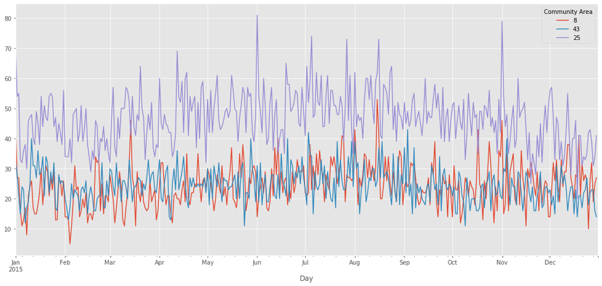

```python
#Community Areas: las tres primeras Community areas con mayores crimenes: Austin, Near North Side y South Shore
community_crime_byday[[8,43,25]].plot();
```

### Parte voluntaria

Descargue la base de datos de información socioeconómica (https://data.cityofchicago.org/Health-Human-Services/Census-Data-Selected-socioeconomic-indicators-in-C/kn9c-c2s2).

### 4.

Cree una tabla que agregue el número de crímenes por Community Area. Una esa tabla con la de datos socioeconómicos y cree un "scatter plot" de número de crímenes vs ingreso per cápita. Explique la relación en palabras.

```python
crimes_by_community2 = crimes.groupby('Community Area')
community_crimes_count2 = crimes_by_community2['ID'].agg('count')
table_crimes_by_community_area=community_crimes_count2.to_frame()
```

```python
# cree la tabla de crimenes por community area
table_crimes_by_community_area
```

| Community Area | ID |
| --- | --- |
| 1 | 3519 |
| 2 | 3059 |
| 3 | 3585 |
| 4 | 1747 |
| 5 | 1375 |
| ... | ... |
| 73 | 3109 |
| 74 | 608 |
| 75 | 2052 |
| 76 | 1622 |
| 77 | 2209 |

77 rows × 1 columns

```python
#adjunte la base de datos como percapita
percapita= pd.read_csv('Census_Data_-_Selected_socioeconomic_indicators_in_Chicago__2008___2012.csv')
```

```python
#cambie el nombre de la columna "Community Area Number" por "Community Area"
percapita.rename(columns={"Community Area Number": "Community Area"}, inplace=True)
```

```python
percapita
```

|  | Community Area | COMMUNITY AREA NAME | PERCENT OF HOUSING CROWDED | PERCENT HOUSEHOLDS BELOW POVERTY | PERCENT AGED 16+ UNEMPLOYED | PERCENT AGED 25+ WITHOUT HIGH SCHOOL DIPLOMA | PERCENT AGED UNDER 18 OR OVER 64 | PER CAPITA INCOME | HARDSHIP INDEX |
| --- | --- | --- | --- | --- | --- | --- | --- | --- | --- |
| 0 | 1.0 | Rogers Park | 7.7 | 23.6 | 8.7 | 18.2 | 27.5 | 23939 | 39.0 |
| 1 | 2.0 | West Ridge | 7.8 | 17.2 | 8.8 | 20.8 | 38.5 | 23040 | 46.0 |
| 2 | 3.0 | Uptown | 3.8 | 24.0 | 8.9 | 11.8 | 22.2 | 35787 | 20.0 |
| 3 | 4.0 | Lincoln Square | 3.4 | 10.9 | 8.2 | 13.4 | 25.5 | 37524 | 17.0 |
| 4 | 5.0 | North Center | 0.3 | 7.5 | 5.2 | 4.5 | 26.2 | 57123 | 6.0 |
| ... | ... | ... | ... | ... | ... | ... | ... | ... | ... |
| 73 | 74.0 | Mount Greenwood | 1.0 | 3.4 | 8.7 | 4.3 | 36.8 | 34381 | 16.0 |
| 74 | 75.0 | Morgan Park | 0.8 | 13.2 | 15.0 | 10.8 | 40.3 | 27149 | 30.0 |
| 75 | 76.0 | O'Hare | 3.6 | 15.4 | 7.1 | 10.9 | 30.3 | 25828 | 24.0 |
| 76 | 77.0 | Edgewater | 4.1 | 18.2 | 9.2 | 9.7 | 23.8 | 33385 | 19.0 |
| 77 | NaN | CHICAGO | 4.7 | 19.7 | 12.9 | 19.5 | 33.5 | 28202 | NaN |

78 rows × 9 columns

```python
#para unir la tabla a la base datos "percapita" utilizo "pd.merge"
pib_percapita_income = pd.merge(percapita, table_crimes_by_community_area, on='Community Area')
```

```python
# al ejecutar el codigo se evidencia la columna "ID"
pib_percapita_income
```

|  | Community Area | COMMUNITY AREA NAME | PERCENT OF HOUSING CROWDED | PERCENT HOUSEHOLDS BELOW POVERTY | PERCENT AGED 16+ UNEMPLOYED | PERCENT AGED 25+ WITHOUT HIGH SCHOOL DIPLOMA | PERCENT AGED UNDER 18 OR OVER 64 | PER CAPITA INCOME | HARDSHIP INDEX | ID |
| --- | --- | --- | --- | --- | --- | --- | --- | --- | --- | --- |
| 0 | 1.0 | Rogers Park | 7.7 | 23.6 | 8.7 | 18.2 | 27.5 | 23939 | 39.0 | 3519 |
| 1 | 2.0 | West Ridge | 7.8 | 17.2 | 8.8 | 20.8 | 38.5 | 23040 | 46.0 | 3059 |
| 2 | 3.0 | Uptown | 3.8 | 24.0 | 8.9 | 11.8 | 22.2 | 35787 | 20.0 | 3585 |
| 3 | 4.0 | Lincoln Square | 3.4 | 10.9 | 8.2 | 13.4 | 25.5 | 37524 | 17.0 | 1747 |
| 4 | 5.0 | North Center | 0.3 | 7.5 | 5.2 | 4.5 | 26.2 | 57123 | 6.0 | 1375 |
| ... | ... | ... | ... | ... | ... | ... | ... | ... | ... | ... |
| 72 | 73.0 | Washington Height | 1.1 | 16.9 | 20.8 | 13.7 | 42.6 | 19713 | 48.0 | 3109 |
| 73 | 74.0 | Mount Greenwood | 1.0 | 3.4 | 8.7 | 4.3 | 36.8 | 34381 | 16.0 | 608 |
| 74 | 75.0 | Morgan Park | 0.8 | 13.2 | 15.0 | 10.8 | 40.3 | 27149 | 30.0 | 2052 |
| 75 | 76.0 | O'Hare | 3.6 | 15.4 | 7.1 | 10.9 | 30.3 | 25828 | 24.0 | 1622 |
| 76 | 77.0 | Edgewater | 4.1 | 18.2 | 9.2 | 9.7 | 23.8 | 33385 | 19.0 | 2209 |

77 rows × 10 columns

```python
# aqui confirmo la existencia de la columna "ID"
pib_percapita_income.columns
```

```
Index(['Community Area', 'COMMUNITY AREA NAME', 'PERCENT OF HOUSING CROWDED',
       'PERCENT HOUSEHOLDS BELOW POVERTY', 'PERCENT AGED 16+ UNEMPLOYED',
       'PERCENT AGED 25+ WITHOUT HIGH SCHOOL DIPLOMA',
       'PERCENT AGED UNDER 18 OR OVER 64', 'PER CAPITA INCOME ',
       'HARDSHIP INDEX', 'ID'],
      dtype='object')
```

```python
#realizo una indexacion con la columna "PER CAPITA INCOME" y "ID" a la cual llamé "crimes_vs_percapita_income"
crimes_vs_percapita_income = pib_percapita_income.loc[1:78,['PER CAPITA INCOME ','ID']]
```

```python
#al ejecutar el codigo se evidencia "crimes_vs_percapita_income"
crimes_vs_percapita_income
```

|  | PER CAPITA INCOME | ID |
| --- | --- | --- |
| 1 | 23040 | 3059 |
| 2 | 35787 | 3585 |
| 3 | 37524 | 1747 |
| 4 | 57123 | 1375 |
| 5 | 60058 | 5495 |
| ... | ... | ... |
| 72 | 19713 | 3109 |
| 73 | 34381 | 608 |
| 74 | 27149 | 2052 |
| 75 | 25828 | 1622 |
| 76 | 33385 | 2209 |

76 rows × 2 columns

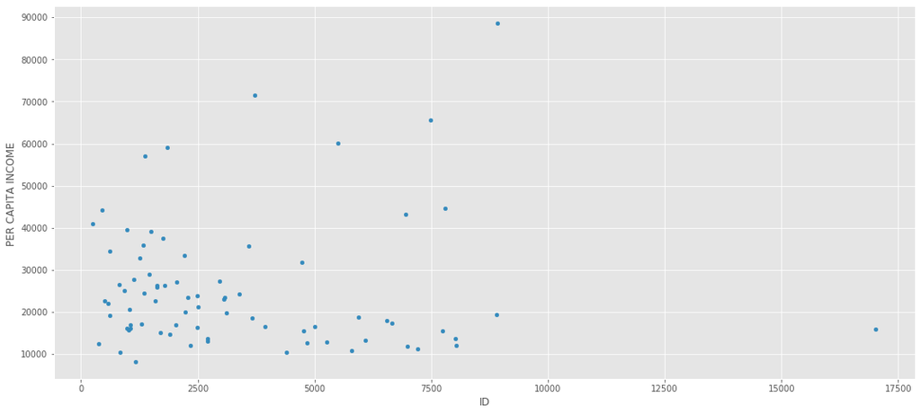

```python
#realizo el scatter plot con "crimes_vs_percapita_income"
my_plot = crimes_vs_percapita_income.plot('ID', 'PER CAPITA INCOME ', kind="scatter")
plt.show()
```

Comentario: se evidencia que la mayor concentración de crimenes se da en aquellas areas donde el ingreso per capita oscila entre 10.000 y 30.000 dolares, es decir en aquella población donde sus ingresos en promedio no son relativamente altos; y a medida que aumenta el ingreso percapita disminuye la concentración de crimenes registrados.

Con ello, superficialmente se puede evidenciar que a mayor ingreso percapita, menor numero de concentracion de crimenes se registran, y a menor ingreso percapita se registra una mayor concentración de numero de crimenes. Sin embargo, no es prudente afirmar la existencia de alguna relación perfecta entrega ambas variables, toda vez que probablemente existan otras variables que pueden explicar el efecto causal.